# SRNM_Modeling-Course

Ernest Fotsing, PostDoctoral Researcher, UniFR/SIB, Switzerland, Personal_Website: https://fotsing2023.github.io/ernestfotsing-website/

2026-10-07

## **Topic: SNRM Training / Modeling in R**

This course provides an overview of modern regression-based statistical analysis techniques relevant to ecological research and applied conservation, starting with basic linear models and moving quickly to generalized linear models (GLMs) and mixed models. The course aims to provide a robust understanding of the wide range of regression approaches available, the assumptions associated with each, and the circumstances under which each should be applied. Models covered enjoy widespread use in ecology and conservation biology and can be applied to a huge diversity of data types, study designs, and research questions. Emphasis is placed not only on proper implementation of models, but also on interpretation and explanation of results, recognizing uncertainty and model limitations. Participants will conduct all exercises using R, a free software environment for statistical computing and graphics which has now become the standard in this field. All exercises and demos will use real ecological data sets.

### **Participants Learning Outcomes**

By the end of this course, participants will be able to: • Import data into R and properly format and clean these data to prepare for analysis • Explore, describe, and manipulate data sets to identify strengths and work around weaknesses • Select an appropriate regression framework based on the type of data and research objectives • Understand regression methods, including assumptions, limits, and applications • Perform model selection and testing for model fit and performance • Understand, interpret, visualize, and present results with associated uncertainties • Use R for their day-to-day statistical and data management work

### **This course covers**

• Introduction to probability theory, random variables, and statistical distributions • Linear models (univariate, multivariate) • Generalized linear models (Poisson, quasi-Poisson, negative binomial, and binomial) • Linear mixed models and generalized linear mixed models • Testing for model assumptions and model • Proper use of data transformations to improve model performance and fulll assumptions • Evaluating model performance with diagnostic tools • Preparing quality graphics and interpreting results • Dealing with common problems in data including missing data and collinearity

• Tips and tricks of programming in R • Organizing analyses into data exploration, descriptive statistics, model application, model diagnostics, and discussion of results. Software and Programs All exercises and some lectures will be performed in R, through user friendly interface RStudio.

Pre-course work will be suggested for all participants not familiar with the program R.

All participants should have a basic familiarity working in the R environment by the time the course begins.

# 1. Installing R and RStudio

In this course, we will use **R** within the **RStudio IDE (Integrated Development Environment)**.  
RStudio is an interface to R and Python (and a number of other computer languages) that has numerous advantages over using R’s built-in interface.  
The RStudio IDE provides loads of tools for an effective and well-organized R data workflow.

## Install and Open RStudio

1. **Install R**  
   If you do not have the most recent version of R installed on your computer, please visit:
   - [R Project for Statistical Computing](https://www.r-project.org/)
   - [CRAN Download Page](https://cran.r-project.org/)
   - [Base R Source Releases](https://cran.r-project.org/src/base/R-4)

   Follow the directions to install R.
2. **Install RStudio**  
   You can directly download and install RStudio onto your computer by following this link:
   - [RStudio Download](https://www.rstudio.com/products/rstudio/download/)
3. **Verify Installation**  
   Please ensure that both **R** and **RStudio** are properly installed on your computer.
4. **Open RStudio and Create a Script**  
   Open RStudio and create a blank script file by pressing the keyboard shortcut:
   - **Windows/Linux:** `CTRL + Shift + N`
   - **Mac:** `⌘ + Shift + N`

## **I. Practise before the course**

### **1.1 Getting Started with R: The Swirl Package and other Resources**

Dr. Brian Evans has developed some excellent online tutorials to help with the basics of R and RStudio. Even if you are familiar with R, this is a great way to refresh some basic concepts. Those without at least some basic familiarity with R will struggle with some portions of the course in January, so I want to stress how important it is that beginners spend time to learn the basics of R before arriving. We will review many of these concepts very briefly in the early parts of the course, but we will move fairly quickly from there.

### **Required Pre-Course Work**

1. [Introduction to R and R studio](https://smbc.shinyapps.io/L0-intro_RStudio/)
2. [Lesson 1. Values](https://smbc.shinyapps.io/L1-rValues/#section-characters)
3. [Lesson 2. Objects](https://smbc.shinyapps.io/L2-rObjects/)
4. [Lesson 3. indexing](https://smbc.shinyapps.io/L3-indexing/#section-introduction).
5. [Lesson 4. Everything you need in R](https://www.geeksforgeeks.org/r-language/r-tutorial/).

### **What I would recommend and that is mandatory for the training**

Introductory lessons in the Swirl package in R. There is an online guide Dr. Evans has posted that will guide you through getting started with Swirl [Introduction to Swirl package](https://smbc-nzp.github.io/dataSci/swirl.html).

#### **SWIRL Lessons**.

To best prepare you for this course, we ask that you complete lessons 1 through 8 of the R Programming SWIRL course. Begin by typing swirl() in your console. When prompted, select “R Programming: The basics of programming in R” (selection 1) and “R programming” (selection 1) in the following menu (if applicable). Select the appropriate lesson from the list of options to continue.

Have fun!

If you want to practice your R skills before the course, here are two (of many) great resources out there:

- [R Programming for Beginners | Complete Tutorial | R & RStudio](https://www.youtube.com/watch?v=BvKETZ6kr9Q) — Great introductory videos to working in R.
- [Modern R with the tidyverse](https://b-rodrigues.github.io/modern_R/) — A book introducing tidyverse data manipulation.
- [if you want to train how to write some basic function dowload these example data](https://github.com/Fotsing2023/Ernest_UY1ModelingTraining/raw/main/example.xlsx/) — witz help you to train with script called Ernest_PracticalFunction.R that was shared with you in the precourse folders.

## **1. Getting Started**

### **Exercice before we start the first days of training**

##### **Please practice this exercice and ask question before we start**

### **The goal of this exercice is to**

Hint: You will find data to reproduce the script below in a zip file calld Data_Precourse.zip that was share with you.

1. Know how to install packages in R
2. Read/Load various extension file in R
3. Perform summary statistics in R
4. Perform T.test, histogram, boxplot, qqline plot, Two sample t.test (paired and Unpaired) in R
5. Perform ANOVA, Wilcoxon, and analysis of variance

### **1.1 Installing Packages**

```r
install_and_load_packages <- function() {
  # List of required packages
  packages <- c(
    "openxlsx", "WriteXLS", "writexl", "raster", "sp", "sf",
    "parallel", "readr", "sfheaders", "stars", "terra", "Matrix",
    "lattice", "abind", "xlsx", "usdm", "AICcmodavg", "corrplot",
    "tidyverse", "coefplot", "GGally", "pgirmess", "influence.ME",
    "MuMIn", "DHARMa", "dplyr", "MASS", "ncf", "visreg"
  )

  # Install any packages that are missing
  new_packages <- packages[!(packages %in% installed.packages()[,"Package"])]
  if(length(new_packages)) {
    message("Installing missing packages: ", paste(new_packages, collapse = ", "))
    install.packages(new_packages, dependencies = TRUE)
  }

  # Load all packages
  invisible(lapply(packages, function(pkg) {
    suppressPackageStartupMessages(library(pkg, character.only = TRUE))
  }))

  # Set ggplot theme
  if ("ggplot2" %in% loadedNamespaces()) {
    ggplot2::theme_set(ggplot2::theme_bw(base_size = 12))
  }

  message("all packages installed and loaded successfully!")
}
```

### **1.2 Basic introduction**

```r
rm(list= ls()) #To remove all objects, issue the command
```

```r
#---------let's read our script from my git repository------------------
#first get the HTML file
dir.create("Lm_script", showWarnings = FALSE)

url <- "https://github.com/Fotsing2023/SNRM5_Ghana/blob/main/SumaryStat_Intro/R_Basic_Introduction.html"

file_path <- file.path("Lm_script", "SumaryStat_Intro.html")

download.file(url, file_path, mode = "wb")

# get the script

url <-  "https://github.com/Fotsing2023/SNRM5_Ghana/blob/main/SumaryStat_Intro/Summary_Stat.R"
file_path <- file.path("Lm_script", "Summary_Stat.R")

download.file(url, file_path, mode = "wb")

url <- "https://github.com/Fotsing2023/SNRM5_Ghana/blob/main/SumaryStat_Intro/Modeling_Data.zip"
file_path <- file.path("./SNRM5", "Modeling_Data.zip")

download.file(url, file_path, mode = "wb")
```

#### **1.2.a. Loading data into R/RStudio**

Data can be saved in a file into your computer as local Excel, SPSS, or some other type of file. Before you move on and discover how to load your data into R, it might be useful to go over the following checklist that will make it easier to import the data correctly into R: For spreadsheets, the first row is usually reserved for the header, while the first column is used to identify the sampling unit; Avoid names, values or fields with blank spaces, otherwise each word will be interpreted as a separate variable, resulting in errors that are related to the number of elements per line in your data set; If you want to concatenate words, inserting a . in between the words instead of a space. E.g ‘French bean’ should be typed as ‘French.bean’ or ‘Frenchbean’ or ‘French bean’. Short names are prefered over longer names; Try to avoid using names that contain symbols such as 2, $,%, A. Delete any comments that you have made in your Excel file to avoid extra columns or NA’s to be added to your file; and Make sure that any missing values in your data set are indicated with NA.

#### **1.2.a1.Importing TXT files (Text or Tab delimited**

```r
#If you have a . txt or a tab-delimited text file, you can easily import it with the basic R function
#imported as follows:
#Imf <- read.table ("yourfile.txt" , header = TRUE)
#Imf<—read. table ("leaf miner fly.csv", header=T, sep= " , " ) ## note the sep argu.
#Imfcl<—read.csv("leaf miner fly.csv")  I do not need the sep argu here

# library (readxl) df <— read excel ("<name and extension of your file>" )
# You can also add a sheet argument:
# df <— read excel ("<name and extension of your file>" sheet—I)
```

```r
#exemple of table you you'have
knitr::kable(head(mtcars[, 1:4]), "simple")
```

|  | mpg | cyl | disp | hp |
| --- | --- | --- | --- | --- |
| Mazda RX4 | 21.0 | 6 | 160 | 110 |
| Mazda RX4 Wag | 21.0 | 6 | 160 | 110 |
| Datsun 710 | 22.8 | 4 | 108 | 93 |
| Hornet 4 Drive | 21.4 | 6 | 258 | 110 |
| Hornet Sportabout | 18.7 | 8 | 360 | 175 |
| Valiant | 18.1 | 6 | 225 | 105 |

```r
iris2 <- head(iris)
knitr::kable(iris2, col.names = gsub("[.]", " ", names(iris)))
```

| Sepal Length | Sepal Width | Petal Length | Petal Width | Species |
| --- | --- | --- | --- | --- |
| 5.1 | 3.5 | 1.4 | 0.2 | setosa |
| 4.9 | 3.0 | 1.4 | 0.2 | setosa |
| 4.7 | 3.2 | 1.3 | 0.2 | setosa |
| 4.6 | 3.1 | 1.5 | 0.2 | setosa |
| 5.0 | 3.6 | 1.4 | 0.2 | setosa |
| 5.4 | 3.9 | 1.7 | 0.4 | setosa |

### **1.2.b.Part IV: t-test**

One sample t-test A one sample t-test compares a sample mean to a given hypothesized mean value. Example: The mean yield for a certain crop is 8 kg/m2. This year, a new pesticide was applied and the yield from nine randomly selected plots are: 9.3 8.2 7.9 8.8 9.4 8.6 8.9 9.5 9.0 Any evidence that yield has increased? Test the Ho: = 8.0 against Ha: >8.0 We create a simple vector of yield using the function c( )

```r
yield <- c(9.3,8.2,7.9,8.8,9.4,8.6,8.9, 9.5,9.0) # create an object 'yield'
yield   # to show contents of obj ect 'yield'
```

```
## [1] 9.3 8.2 7.9 8.8 9.4 8.6 8.9 9.5 9.0
```

Before undertaking any statistical analysis it is good to explore the data. We start with numerical summaries.

```r
yield <- c(9.3,8.2,7.9,8.8,9.4,8.6,8.9, 9.5,9.0)
summary(yield)  # to surrmarise the variable 'yield'
```

```
##    Min. 1st Qu.  Median    Mean 3rd Qu.    Max.
##   7.900   8.600   8.900   8.844   9.300   9.500
```

What is the estimated mean yield from the sample? .

Before we do the t-test we check the distribution of the data using histogram, boxplot, normal qqplot or stem and leaf.

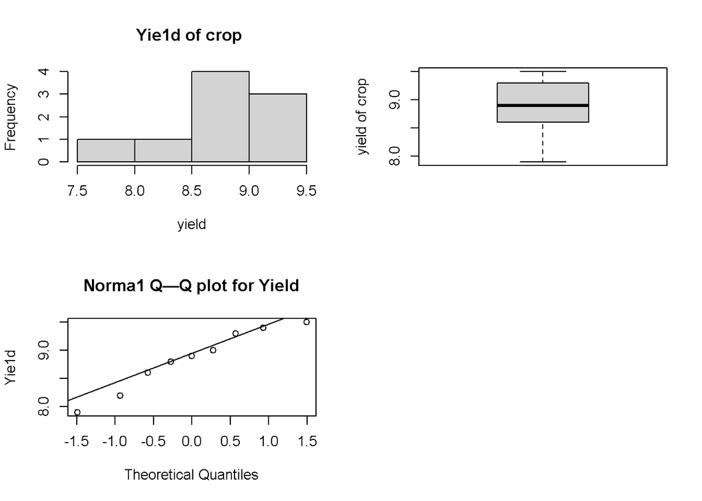

```r
par (mfrow=c (2 , 2) ) #multifigure display for the graphs
hist(yield, main="Yie1d of crop " ) #histogram of yield plus main title
boxplot(yield, ylab= "yield of crop") #boxplot with y axis title
qqnorm (yield, main="Norma1 Q—Q plot for Yield" , ylab="Yie1d") #normal plot
qqline(yield)   # adding a line onto the normal plot
```

What is your comment regarding the normality assumption on the data?

Finally, we might want a more formal test of agreement with normality, testing the following hypothesis Ho: The distribution is normal HA: The distribution is NOT normal R provides the Shapiro-Wilk test:

```r
shapiro.test(yield) # do a Shapiro—Wilk test on 'yield'
```

```
##
##  Shapiro-Wilk normality test
##
## data:  yield
## W = 0.94626, p-value = 0.6491
```

Alternatively, we use the Kolmogorov-Smirnov test using ks.test() function

```r
ks.test(yield, "pnorm", mean = mean(yield), sd = sd(yield))
```

```
##
##  Exact one-sample Kolmogorov-Smirnov test
##
## data:  yield
## D = 0.13393, p-value = 0.9896
## alternative hypothesis: two-sided
```